# TCE - Building Healthy Communities

draft

9/26/2019

## Plot of Existing Counties and Regions

- Counties located on the right side of the plot has more disparate outcomes across race and ethnic groups than those on the left side.

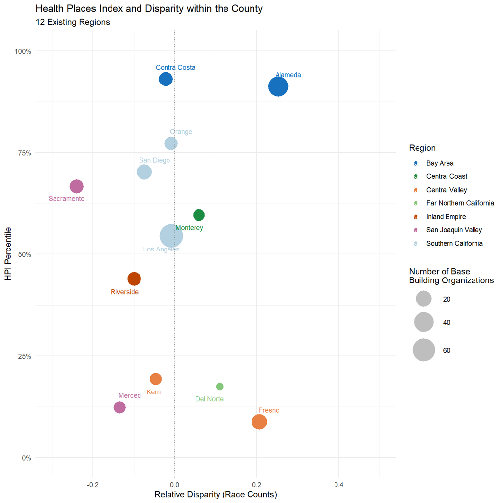

## Plot of Expanded Regions

- Counties located on the right side of the plot has more disparate outcomes across race and ethnic groups than those on the left side.

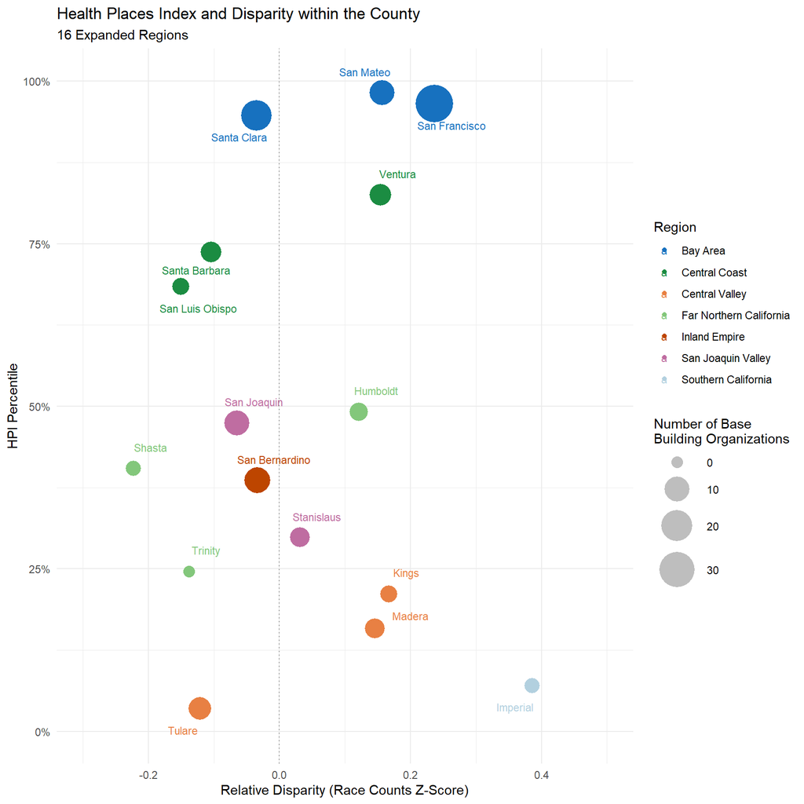

## Regional Plot Options:

### Individual Plots: Example of Far Northern California

- Counties located on the right side of the plot has more disparate outcomes across race and ethnic groups than those on the left side.
- Note that the y-axis is relative to the range of values in the region (y-axis can also be fixed, but the relative y-axis makes it easier to see within-region differences).

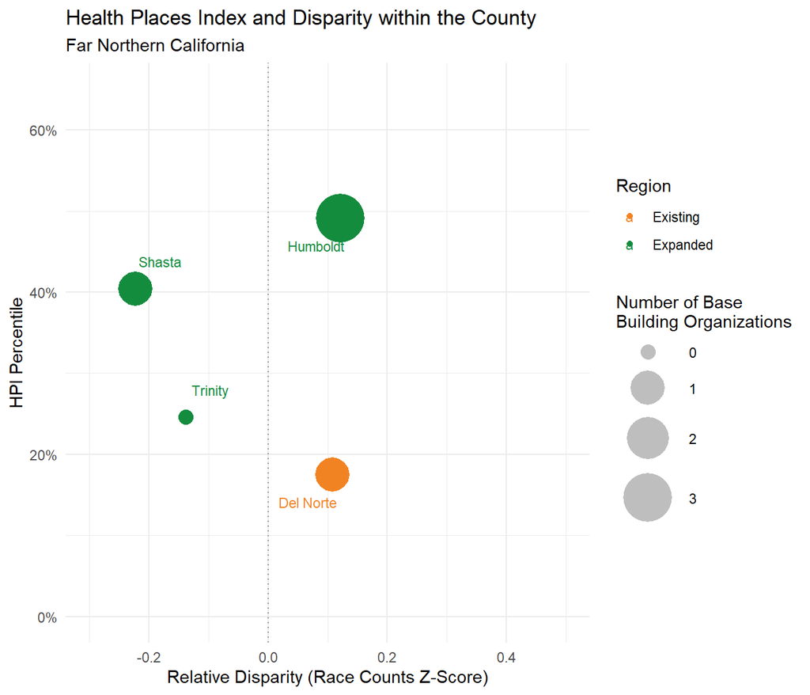

- Counties located on the right side of the plot has more disparate outcomes across race and ethnic groups than those on the left side.
- Note that the y-axis is relative to the range of values in the region (y-axis can also be fixed, but the relative y-axis makes it easier to see within-region differences).

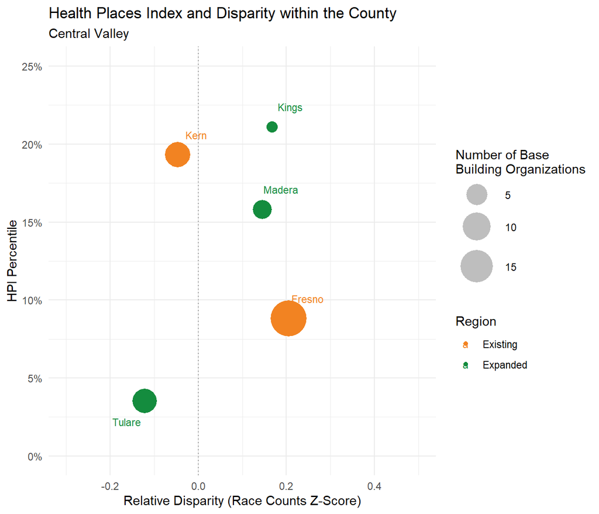

## Plot of Existing + Expanded Regions

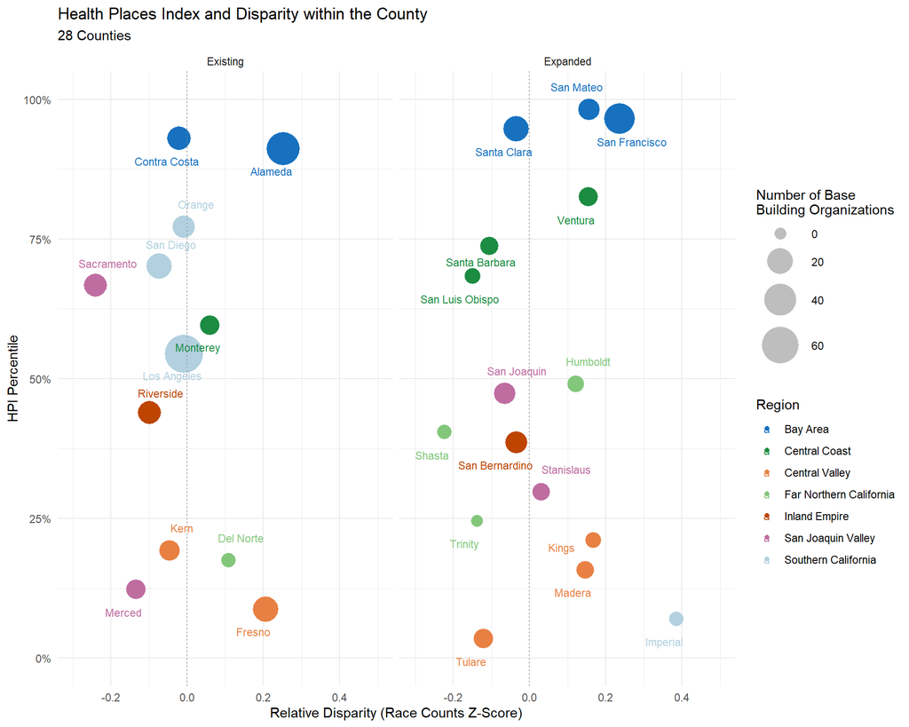